# Exam 1

Ariana Fairbanks

9/13/2018

## Instructions

Presumably, you have already created a new project and downloaded this file into it. Please knit the document and work back and forth between this R Markdown file and the PDF output as you work through this module.

When you are finished with the assignment, knit to PDF one last time, proofread the PDF file **carefully**, export the PDF file to your computer, and then submit your assignment.

Sometimes you will be asked to add your own R code. That will appear in this document as a code chunk with a request for you to add your own code, like so:

```r
## Add code here to [do some task]...
```

Be sure to remove the line `## Add code here to [do some task]...` when you have added your own code.

1.0

Sometimes you will be asked to type up your thoughts. That will appear in the document as follows:

# Please write your answer here.

Again, please be sure to remove the line “Please write up your answer here” when you have written up your answer. In these areas of the assignment, please use contextually meaningful full sentences/paragraphs (unless otherwise indicated) and proper spelling, grammar, punctuation, etc. This is not R code, but rather a free response section where you talk about your analysis and conclusions. If you need to use some R code as well, you can use inline R code inside the block between `\begin{answer}` and `\end{answer}`, or if you need an R code chunk, please go outside the `answer` block and start a new code chunk.

## Load Packages

We load the `mosaic` package as well as the `MASS` package for working with data on risk factors associated with low birth weight. (Note that the `ggplot2` package we will use for graphing is automatically loaded alongside the `mosaic` package.)

```r
library(mosaic)
library(MASS)
library(gmodels)
```

## Questions

1. Recall the data base birthwt from the library (MASS). How many wariables are there? For the variable birth weight in grams calculate the folowing characteristics:
1. mean

```r
mean(birthwt$bwt)
```

```
[1] 2944.587
```

2. median

```r
median(birthwt$bwt)
```

```
[1] 2977
```

3. Q1, Q2, Q3 and IQR

```r
#using quantile like this is faster than finding Qs individually
quantile(birthwt$bwt)
```

```
  0%  25%  50%  75% 100%
 709 2414 2977 3487 4990
```

```r
IQR(birthwt$bwt)
```

```
[1] 1073
```

4. standard deviation

```r
sd(birthwt$bwt)
```

```
[1] 729.2143
```

5. variance

```r
var(birthwt$bwt)
```

```
[1] 531753.5
```

6. Calculate the summary statistics

```r
summary(birthwt$bwt)
```

```
   Min. 1st Qu.  Median    Mean 3rd Qu.    Max.
    709    2414    2977    2945    3487    4990
```

Explain which of these data characteristics are robust statistics and why.

The median and the IQR are robust because they look at the data at specific points. Because of this, it doesn’t matter much if you have a few outliers because it has little effect on the positioning of the rest of the data.

2.Build a histogram for the data connected to the baby’s weight.Comment the shape, mode, outliers. Make sure you adjust the binwidth and the boundary such that you get a meaningful histogram. Make sure you add a title and label x axis.

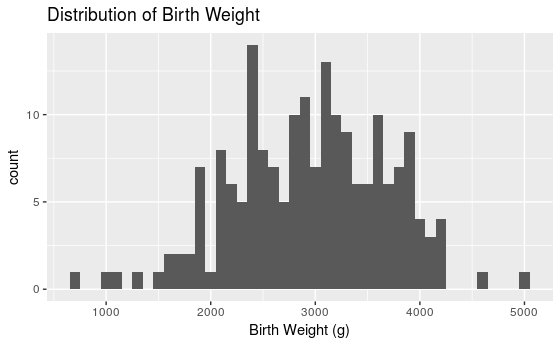

```r
ggplot(birthwt, aes(x = birthwt$bwt)) + geom_histogram(binwidth = 100, boundary = 50) + labs(title = "Distribution of Birth Weight", x = "Birth Weight (g)")
```

3. Choose the lwt and the bwt from birthwt database. Create a scatter plot. Make sure you add a title and label the x and y axis.

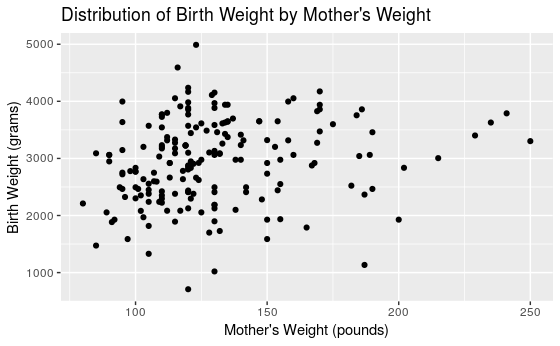

```r
ggplot(birthwt, aes(y = bwt, x = lwt)) +
    geom_point() + labs(title = "Distribution of Birth Weight by Mother's Weight", x = "Mother's Weight (pounds)", y = "Birth Weight (grams)")
```

Which variable is explanatory and which one is response? Are they associated?

The mother’s weight is the explanitory variable and the birth weight is the response. There doesn’t seem to be any correlation between the two.

4. 1. Choose the variable smoke from the birthwt. Create a factor variable and put this in a data frame (call this smoke_df).

```r
smoke <- factor(birthwt$smoke,
                levels = c(1, 0),
                labels = c("Yes", "No"))
smoke_df <- data.frame(smoke)
```

2. Create a frequency table (use percentages) for smoke_df$smoke.(Hint: use tally command)

```r
tally(~ smoke, data = smoke_df, format = "percent")
```

```
smoke
     Yes       No
39.15344 60.84656
```

What is the percentage of the mothers that smoke?

About 39.2%

3. Create a bar plot of this categorical variable (hint: make sure you use smoke_df). Make sure you add a title and label the axes.

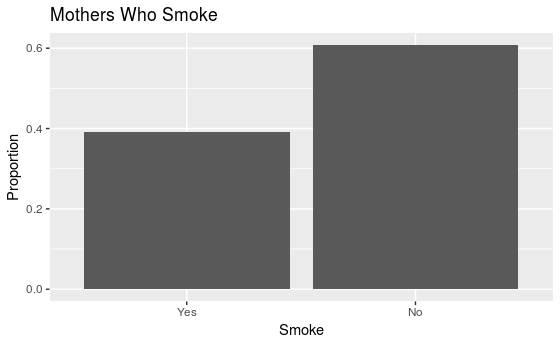

```r
ggplot(smoke_df, aes(x = smoke, y = ..prop.., group = 1)) +
    geom_bar() + labs(title = "Mothers Who Smoke", x = "Smoke", y = "Proportion")
```

4. Choose two categorical variables of interst from birthwt data set. Turn them into factor variables with meaningful labels. Create a new data frame containing both variables. Identify one as explanatory and one as response. Then create a contingency table with row percentages, Comment on the association (or independence) of the two variables.

```r
race <- factor(birthwt$race,
               levels = c(1, 2, 3),
               labels = c("White", "Black", "Other"))
smoke_race <- data.frame(smoke, race)
tally(smoke ~ race, data = smoke_race, margins = FALSE, format = "percent")
```

```
     race
smoke    White    Black    Other
  Yes 54.16667 38.46154 17.91045
  No  45.83333 61.53846 82.08955
```

The percentage of women who smoked during their pregnancy varied significantly between the races. For example, about 54% of white women smoked compared to about 18% of ‘other’ women. This implies that there is some association between the two.

5. Choose two categorical variables of interst from birthwt data set. Turn them into factor variables with meaningful labels. Create a new data frame containing both variables. Identify one as explanatory and one as response.Then create a side-by-side bar chart.Comment on the association (or independence) of the two variables.These variables can be the same with the ones in part d).

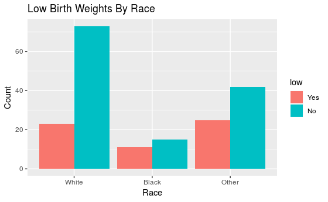

```r
low <- factor(birthwt$low,
                levels = c(1, 0),
                labels = c("Yes", "No"))
low_race <- data.frame(low, race)
ggplot(low_race, aes(fill = low, x = race)) +
    geom_bar(position = "dodge") +
    labs(title = "Low Birth Weights By Race",
         y = "Count",
         x = "Race")
```

I couldn’t figure out how to make the y axis proportional, but it appears there might be some association. For example, about 42% of black women had a low birth weight compared to only about 24% of white women.

5. Choose an interesting numerical variable and an interesting categorical variable from the `birthwt` data set. (Choose at least one variable you haven’t used already.) Convert the categorical variable to a factor variable. Create a data frame with your chosen variables. Then make both a side-by-side boxplot. Discuss the resulting graphs. Comment on the association (or independence) of the two variables. Make sure you add a title and label the axes.

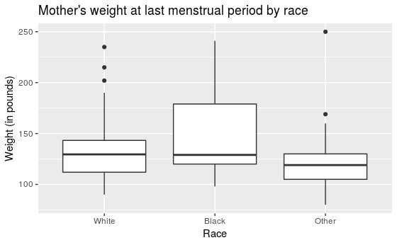

```r
lwt_race <- data.frame(lwt = birthwt$lwt, race)
ggplot(lwt_race, aes(y = lwt, x = race)) +
    geom_boxplot() +
    labs(title = "Mother's weight at last menstrual period by race",
         y = "Weight (in pounds)",
         x = "Race")
```

It seems that black women who were above the median had a greater distribution of their weights, but there doesn’t seem to be any correlation between the variables.